# Statistical Inference - Project

Gareth Coffey

26/05/2021

## Overview

This is a paper that consists of two parts: 1. A simulation exercise investigating the exponential distribution in R and comparing it with the Central Limit Theorem (CLT). 2. Inferential data analysis of the ToothGrowth data in the R datasets pacakge.

## Part 1 - Simulations investigating the exponential distribution in R

Here I perform the simulations of the exponentials and then calculate the means of those exponentials:

First, I replicate 1000 times the simulation of the exponential distribution using the expression rexp(n, lambda)

```r
simulation_of_exponentials <- replicate(nosim, rexp(n, lambda))
means_of_exponentials <- apply(simulation_of_exponentials, 2, mean)
```

Some basic exploration of the simulation:

```r
# Number of rows and columns of data:
dim(simulation_of_exponentials)
```

```
## [1]   40 1000
```

```r
# Value range of the data:
range(simulation_of_exponentials)
```

```
## [1] 8.195983e-06 6.104031e+01
```

```r
# First 10 values in the data:
simulation_of_exponentials[0:10]
```

```
##  [1]  0.3752038  1.8535227  6.7953219  0.7189461  0.3205374  4.5755572
##  [7]  4.6738252  4.4648434  0.3227221 13.8080176
```

### Sample Mean versus Theoretical Mean

#### Question 1 - Show the sample mean and compare it to the theoretical mean of the distribution.

```r
sample_mean <- mean(means_of_exponentials)
theoretical_mean <- 1/lambda
```

The sample mean is:

```
## [1] 4.976277
```

The theoretical mean is:

```
## [1] 5
```

The sample mean is very close to the theoretical mean.

### Sample Variance versus Theoretical Variance

#### Question 2 - Show how variable the sample is (via variance) and compare it to the theoretical variance of the distribution

```r
sd_of_distribution <- sd(means_of_exponentials)
variance_distribution <- sd_of_distribution^2

sd_theoretical <- (1/lambda)/sqrt(n)
variance_theoretical <- ((1/lambda)*(1/sqrt(n)))^2
```

The standard deviation of the sample distribution is:

```
## [1] 0.6027554
```

The standard deviation of the central limit theorem is:

[output not shown]

### Distribution

#### Question 3 - Show the distribution is approximately normal

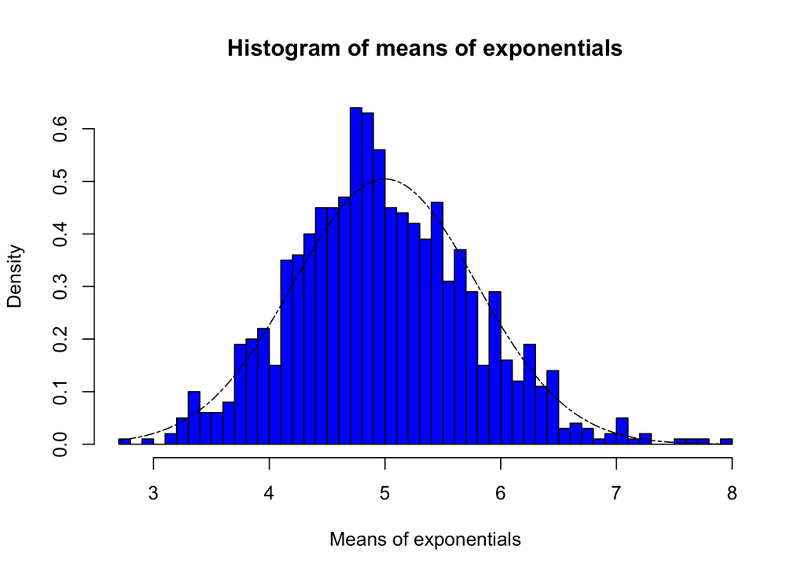

```r
x_axis <- seq(min(means_of_exponentials), max(means_of_exponentials), length=100)
y_axis <- dnorm(x_axis, mean=1/lambda, sd=(1/lambda/sqrt(n)))
hist(means_of_exponentials, breaks=n, prob=T, col="blue", xlab="Means of exponentials", main="Histogram of means of exponentials", ylab="Density")
lines(x_axis, y_axis, pch=22, col="black", lty=6)
```

The distribution of the values is approximately normal as it has the familiar bell-curve.

# Part 2 - Inferential Data Analysis of ToothGrowth data

```r
# Loading the dataset 'ToothGrowth'
data("ToothGrowth")
```

A basic summary of the data:

```r
# A summary of the dataset
summary(ToothGrowth)
```

```
##       len        supp         dose
##  Min.   : 4.20   OJ:30   Min.   :0.500
##  1st Qu.:13.07   VC:30   1st Qu.:0.500
##  Median :19.25           Median :1.000
##  Mean   :18.81           Mean   :1.167
##  3rd Qu.:25.27           3rd Qu.:2.000
##  Max.   :33.90           Max.   :2.000
```

```r
# The first few rows of data
head(ToothGrowth)
```

```
##    len supp dose
## 1  4.2   VC  0.5
## 2 11.5   VC  0.5
## 3  7.3   VC  0.5
## 4  5.8   VC  0.5
## 5  6.4   VC  0.5
## 6 10.0   VC  0.5
```

```r
# The dimensions of the data
dim(ToothGrowth)
```

```
## [1] 60  3
```

```r
# The structure of the data
str(ToothGrowth)
```

```
## 'data.frame':    60 obs. of  3 variables:
##  $ len : num  4.2 11.5 7.3 5.8 6.4 10 11.2 11.2 5.2 7 ...
##  $ supp: Factor w/ 2 levels "OJ","VC": 2 2 2 2 2 2 2 2 2 2 ...
##  $ dose: num  0.5 0.5 0.5 0.5 0.5 0.5 0.5 0.5 0.5 0.5 ...
```

The data set has 60 observations, each with 3 variables: 1. len (number) 2. supp (a factor - supplement type VC or OJ) 3. dose (number)

## Comparing the tooth growth in by supp and dose:

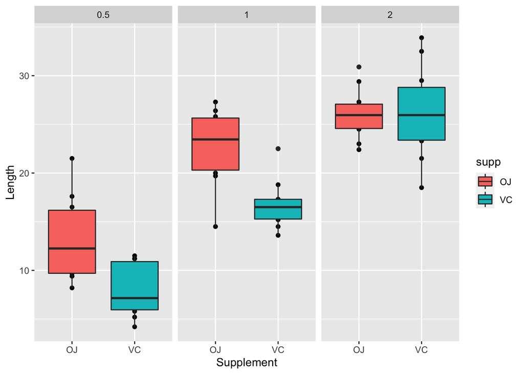

```r
qplot(supp, len, data=ToothGrowth, facets=~dose,xlab="Supplement", ylab="Length") + geom_boxplot(aes(fill=supp))
```

It appears that as the dose increases, the tooth growth increases - this holds true for both supplements.

It seems from the plot above that supplement OJ induces higher relative growth between 0.5 and 1 mg – increasing the dosage to 2mg has little effect.

The growth increases fairly linearly for supplement VC.

## Hypothesis Testing - Assumptions

There are a few assumptions that need to be made about the data before I conduct hypothesis testing:

1. The variables are IID
2. A normal distribution for tooth growth

## Hypothesis Test - Supplement Type

#### Alternative Hypothesis (Ha)

Supplement OJ induces more tooth growth than supplement VC.

#### Testing

First, we need to split the dataset by the type of supplement:

```r
oj_data = ToothGrowth$len[ToothGrowth$supp == 'OJ']
vc_data = ToothGrowth$len[ToothGrowth$supp == 'VC']
```

Conduct a t confidence interval test on the two sets of data:

```r
t.test(oj_data, vc_data, alternative="greater", paired=FALSE, conf.level=0.95)
```

```
##
##  Welch Two Sample t-test
##
## data:  oj_data and vc_data
## t = 1.9153, df = 55.309, p-value = 0.03032
## alternative hypothesis: true difference in means is greater than 0
## 95 percent confidence interval:
##  0.4682687       Inf
## sample estimates:
## mean of x mean of y
##  20.66333  16.96333
```

## Hypothesis Test - Dosage

#### Null Hypothesis (H0)

Dosage does not affect the level of tooth growth.

#### Alternative Hypothesis (Ha)

As dosage increases so does the level of tooth growth.

#### Testing

First, we need to split the dataset by the level of dosage:

```r
doseHalfMg = ToothGrowth$len[ToothGrowth$dose == 0.5]
doseOneMg = ToothGrowth$len[ToothGrowth$dose == 1]
doseTwoMg = ToothGrowth$len[ToothGrowth$dose == 2]
```

Conduct a t confidence interval test on the 0.5mg vs 1mg

```r
t.test(doseHalfMg, doseOneMg, alternative="less", paired=FALSE, conf.level = 0.95)
```

```
##
##  Welch Two Sample t-test
##
## data:  doseHalfMg and doseOneMg
## t = -6.4766, df = 37.986, p-value = 6.342e-08
## alternative hypothesis: true difference in means is less than 0
## 95 percent confidence interval:
##       -Inf -6.753323
## sample estimates:
## mean of x mean of y
##    10.605    19.735
```

Here, the P_value of 6.342e-08 is less than 0.05. Therefore, there is a negligle chance of getting a value that disagrees with our alternative hypothesis for doses of 0.5 and 1mg.

Now, let’s test 1mg and 2mg:

```r
t.test(doseOneMg, doseTwoMg, alternative="less", paired=FALSE, conf.level=0.95)
```

```
##
##  Welch Two Sample t-test
##
## data:  doseOneMg and doseTwoMg
## t = -4.9005, df = 37.101, p-value = 9.532e-06
## alternative hypothesis: true difference in means is less than 0
## 95 percent confidence interval:
##      -Inf -4.17387
## sample estimates:
## mean of x mean of y
##    19.735    26.100
```